# Marjum 2026-07 — B2: Transmitter & Antenna Position, with Defensible Uncertainties

**Milestone:** B2 (Tx/antenna position with defensible uncertainties). **Prepared by:** geometer, 2026-09-13. **Requested by:** experimental-strategist, under Aaron-approved fleet freeze (2026-09-13).

**Question.** What are the best-supported ENU coordinates of the transmitter and the antenna on the working DEM grid, and what uncertainty can we defensibly attach to each — as opposed to a single fit's own training residual?

**Approach.** For both targets we do not trust any single optimizer fit's residual as an uncertainty. Instead:

- **Transmitter:** bound the position by the envelope over independently defensible fit generations, checked against the *only* two cameras (2210, 2211) that are never refit against the transmitter ray and are therefore not circular evidence.
- **Antenna:** report the camera-fixed robust triangulation together with its full per-image reprojection residual table and leave-one-out (LOO) sensitivity, and state plainly where the residual is too large to treat as Gaussian.

This notebook is read-only over already-produced products; it runs no new optimizer fits.

```python
import json
from pathlib import Path

import numpy as np
import matplotlib.pyplot as plt

WORKSPACE = Path('/home/aparsons/projects/eigsep/terrain')
TX_PRODUCT = Path('/mnt/data02/eigsep/marjum-2026-07/curation/transmitter_position.json')
ANT_REPORT = WORKSPACE / 'cv_antenna_repick_v1' / 'report.json'

tx = json.loads(TX_PRODUCT.read_text())
ant = json.loads(ANT_REPORT.read_text())
print('Tx product stamp:', tx['stamp'])
print('Antenna source:', ant['source'])
```

```
Tx product stamp: marjum-2026-07/transmitter_position@v2+360fe99
Antenna source: cv_position_selected_views_v1/fit_selected.npz
```

## 1. Inputs & provenance

Both products are read directly from disk with no recomputation. Hashes and generator commits are recorded in the products themselves; we display them here rather than re-deriving them, to keep this notebook auditable against the exact bytes it read.

```python
print('=== Transmitter position product provenance ===')
prov = tx['provenance']
print('generator:', prov['generator'], '@', prov['generator_commit'])
print('generated_utc:', prov['generated_utc'])
print(f"{'input':55s} sha256[:16]")
for i in prov['inputs']:
    print(f"{i['path']:55s} {i['sha256'][:16]}")

print()
print('=== Antenna repick provenance ===')
print('source:', ant['source'])
print('input_sha256[:16]:', ant['input_sha256'][:16] if isinstance(ant['input_sha256'], str) else ant['input_sha256'])
print('sigma_px:', ant['sigma_px'], ' camera_parameters_fixed:', ant['camera_parameters_fixed'],
      ' distortion_used:', ant['distortion_used'])
```

```
=== Transmitter position product provenance ===
generator: terrain/marjum_tx_uncertainty.py @ 360fe99
generated_utc: 2026-09-13T17:16:29Z
input                                                   sha256[:16]
terrain/cv_transmitter_v1/fit_transmitter.npz           6e5b19efceccb3f3
terrain/cv_transmitter_v3/fit_transmitter.npz           ae5982ab77eecf84
terrain/cv_transmitter_joint_v1/fit_transmitter.npz     82279528f9e8d478
terrain/cv_transmitter_joint_v2/fit_transmitter.npz     8b39e0e68744b53d
terrain/cv_transmitter_joint_v4/fit_transmitter.npz     bb23b3417d175123
terrain/cv_transmitter_joint_probe_trial5/fit_transmitter.npz f3d88393aa84e5bd
terrain/meta.json                                       6f267aed26b3aee4

=== Antenna repick provenance ===
source: cv_position_selected_views_v1/fit_selected.npz
input_sha256[:16]: {'cv_position_selected_views_v1/fit_selected.npz': 'e0c58faeb1f05efdd5dc1862d1b2cb0cc0dbbc4cf5a103226c6c4cda533c902e', 'meta.json': 'ac73d05c5789b42b6d14a4d276ff1d846a2e466b3669e47d26372dfc8be9248b'}
sigma_px: 3.0  camera_parameters_fixed: True  distortion_used: True
```

## 2. Transmitter position — best estimate and uncertainty bracket

**Best estimate (ENU, m):** `[1652.198, 2025.104, 1684.384]` **Uncertainty:** a **1.5 m bounding radius** (not a posterior sigma) — see `marjum_tx_uncertainty.py` / `TRANSMITTER_FIT.md` for the derivation rule.

```python
u = tx['uncertainty']
print('bound_m:', u['bound_m'], '(', u['kind'], ')')
print('methodological_envelope_m:', u['basis']['methodological_envelope_m'])
print('independent_check_max_ray_miss_m:', u['basis']['independent_check_max_ray_miss_m'])
print('rule:', u['basis']['rule'])
print()
print(u['interpretation'])
```

```
bound_m: 1.5 ( bounding radius, not a posterior sigma )
methodological_envelope_m: 0.716
independent_check_max_ray_miss_m: 1.424
rule: bound = ceil(max(envelope, independent_check) * 10) / 10

Treat as a hard bracket on the transmitter position. No fit in this family carries a posterior; every per-fit residual is a training residual. Downstream consumers should propagate the bound, not any single fit's residual scatter.
```

### 2a. Baseline diagnostics — per-generation transmitter position and independent-camera ray miss

The six "conditioned" cameras (2159/2171/2172/2198/2199/2203) are jointly fit against the transmitter ray in every generation below, so their near-zero misses are **circular** and are shown only for completeness — they are not evidence of transmitter accuracy. Only 2210 and 2211 are independent checks. `cv_transmitter_joint_v2` is excluded from the envelope as an outlier (see column).

```python
gens = tx['generations']
rows = []
for name, g in gens.items():
    p = g['transmitter_enu_m']
    ind = g['independent_check_ray_miss_m']
    rows.append((name, p, ind.get('2210'), ind.get('2211'),
                 g['acceptance_accepted'], g['outlier_excluded_from_envelope']))

hdr = f"{'generation':32s} {'E':>9s} {'N':>9s} {'U':>9s} {'2210 miss(m)':>13s} {'2211 miss(m)':>13s} {'accepted':>9s} {'outlier':>8s}"
print(hdr)
print('-' * len(hdr))
for name, p, m2210, m2211, acc, out in rows:
    print(f"{name:32s} {p[0]:9.3f} {p[1]:9.3f} {p[2]:9.3f} "
          f"{('%.3f' % m2210) if m2210 is not None else '—':>13s} "
          f"{('%.3f' % m2211) if m2211 is not None else '—':>13s} "
          f"{str(acc):>9s} {str(out):>8s}")
```

```
generation                               E         N         U  2210 miss(m)  2211 miss(m)  accepted  outlier
-------------------------------------------------------------------------------------------------------------
cv_transmitter_v1                 1652.455  2025.260  1684.732         0.342         0.375      None    False
cv_transmitter_v3                 1652.268  2025.079  1684.665         0.305         0.428      None    False
cv_transmitter_joint_v1           1652.268  2025.079  1684.665         0.305         0.428      None    False
cv_transmitter_joint_v2           1655.355  2025.739  1686.077         1.710         2.870      None     True
cv_transmitter_joint_v4           1651.975  2025.105  1683.704         0.640         1.424     False    False
cv_transmitter_joint_probe_trial5  1652.025  2024.995  1684.155         0.178         0.964      None    False
```

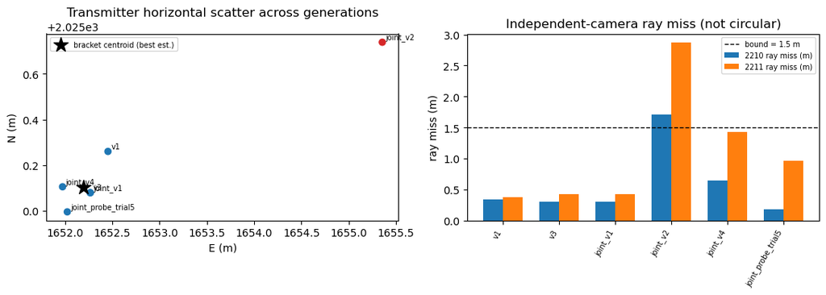

```python
fig, ax = plt.subplots(1, 2, figsize=(11, 4))

names = [n for n in gens]
outlier = [gens[n]['outlier_excluded_from_envelope'] for n in names]
E = [gens[n]['transmitter_enu_m'][0] for n in names]
N = [gens[n]['transmitter_enu_m'][1] for n in names]
U = [gens[n]['transmitter_enu_m'][2] for n in names]
colors = ['tab:red' if o else 'tab:blue' for o in outlier]

ax[0].scatter(E, N, c=colors)
for n, e, nn in zip(names, E, N):
    ax[0].annotate(n.replace('cv_transmitter_', ''), (e, nn), fontsize=7,
                    xytext=(3, 3), textcoords='offset points')
be = tx['best_estimate_enu_m']
ax[0].scatter([be[0]], [be[1]], marker='*', s=200, c='k', label='bracket centroid (best est.)')
ax[0].set_xlabel('E (m)'); ax[0].set_ylabel('N (m)'); ax[0].set_title('Transmitter horizontal scatter across generations')
ax[0].legend(fontsize=7)

m2210 = [gens[n]['independent_check_ray_miss_m'].get('2210') for n in names]
m2211 = [gens[n]['independent_check_ray_miss_m'].get('2211') for n in names]
x = np.arange(len(names))
w = 0.35
ax[1].bar(x - w/2, m2210, width=w, label='2210 ray miss (m)')
ax[1].bar(x + w/2, m2211, width=w, label='2211 ray miss (m)')
ax[1].axhline(u['bound_m'], color='k', ls='--', lw=1, label=f"bound = {u['bound_m']} m")
ax[1].set_xticks(x); ax[1].set_xticklabels([n.replace('cv_transmitter_', '') for n in names],
                                            rotation=60, ha='right', fontsize=7)
ax[1].set_ylabel('ray miss (m)'); ax[1].set_title('Independent-camera ray miss (not circular)')
ax[1].legend(fontsize=7)
fig.tight_layout()
fig.savefig('_b2_tx_diag.png', dpi=140)
plt.show()
```

### 2b. Independent-pair solution (2210 + 2211 alone)

Triangulating **only** from the two cameras that are never conditioned on the transmitter ray gives an independent cross-check on the fit-family envelope above.

```python
ip = tx['independent_pair_solution']
print('reference generation:', ip['reference_generation'])
print('independent-pair solution (ENU):', ip['solution_enu_m'])
print('mutual ray gap (2210 vs 2211):', ip['mutual_ray_gap_m'], 'm')
print('offset from reference (dE, dN, dU, horiz, total):', ip['offset_from_reference_m'])
print()
print(ip['interpretation'])
```

```
reference generation: /home/aparsons/projects/eigsep/terrain/cv_transmitter_joint_v4
independent-pair solution (ENU): [1652.41, 2025.238, 1684.742]
mutual ray gap (2210 vs 2211): 0.715 m
offset from reference (dE, dN, dU, horiz, total): {'dE': 0.435, 'dN': 0.133, 'dU': 1.038, 'horizontal': 0.455, 'total': 1.134}

The two unconditioned cameras agree with each other to 0.7 m and jointly place the transmitter ~1.0 m HIGHER than the v4 joint fit, with only ~0.45 m of horizontal offset. The disagreement is therefore almost purely vertical and is between two camera GROUPS, not a single bad pick.
```

## 3. Antenna position — best estimate and diagnostics

**Best estimate (ENU, m):** `[1655.868, 2030.923, 1777.397]` — camera-fixed robust triangulation, `cv_antenna_repick_v1/fit_antenna.npz`, shifted `[0.221, -0.075, -0.055]` m from the prior (20-view) estimate.

```python
print('initial_antenna:', ant['initial_antenna'])
print('antenna (fitted):', ant['antenna'])
print('shift_m:', ant['shift_m'])
print()
print('residual_median_px:', round(ant['residual_median_px'], 2),
      ' residual_rms_px:', round(ant['residual_rms_px'], 2),
      ' residual_max_px:', round(ant['residual_max_px'], 2))
print('leave-one-out median_px:', round(ant['loo_median_px'], 2),
      ' loo_rms_px:', round(ant['loo_rms_px'], 2),
      ' loo_max_px:', round(ant['loo_max_px'], 2))
print('optimizer:', ant['optimizer'])
```

```
initial_antenna: [1655.6462884019807, 2030.9983849624034, 1777.4518328239405]
antenna (fitted): [1655.8677280505406, 2030.9231204737785, 1777.3965374946242]
shift_m: [0.22143964855990816, -0.07526448862495272, -0.05529532931632275]

residual_median_px: 15.47  residual_rms_px: 24.94  residual_max_px: 50.78
leave-one-out median_px: 20.28  loo_rms_px: 26.46  loo_max_px: 51.85
optimizer: {'cost': 277.7253693962004, 'nfev': 8, 'status': 2, 'message': '`ftol` termination condition is satisfied.'}
```

### 3a. Baseline diagnostics — per-image reprojection residuals

`before` = residual against the prior 20-view antenna estimate; `after` = residual against the refit robust triangulation (23 views, camera poses held fixed). `ray_miss_m` is the corresponding 3-D miss distance.

```python
before = {b['key']: b for b in ant['before']}
after = {a['key']: a for a in ant['after']}
keys = ant['keys']

hdr = f"{'image':8s} {'before px':>10s} {'after px':>9s} {'after ray_miss (m)':>19s}"
print(hdr); print('-' * len(hdr))
for k in keys:
    b = before[k]['error_px']; a = after[k]['error_px']; rm = after[k]['ray_miss_m']
    flag = '  <-- >1 m ray miss' if rm > 1.0 else ''
    print(f"{k:8s} {b:10.2f} {a:9.2f} {rm:19.3f}{flag}")
```

```
image     before px  after px  after ray_miss (m)
-------------------------------------------------
2213          11.02     18.68               0.457
2215          25.65     19.05               0.313
2216           6.34      2.46               0.099
2217          39.13     43.65               1.045  <-- >1 m ray miss
2218           1.21     13.57               0.177
2220           6.22      6.59               0.139
2221          17.21     12.83               0.398
2222           1.51      7.03               0.167
2223           8.02     10.66               0.241
2224          20.63     12.65               0.223
2226           8.69     12.75               0.325
2231          14.84     21.44               0.323
2234          11.59      8.48               0.268
2235          38.96     40.35               1.346  <-- >1 m ray miss
2237          11.34      5.17               0.047
2238          12.83     15.47               0.442
2239           4.74      9.16               0.232
2209          47.17     41.16               1.598  <-- >1 m ray miss
2210          57.59     50.78               1.607  <-- >1 m ray miss
2211          51.81     45.02               1.548  <-- >1 m ray miss
2214          38.25     32.59               0.549
2232          21.31     22.92               1.417  <-- >1 m ray miss
2245          25.78     20.08               0.597
```

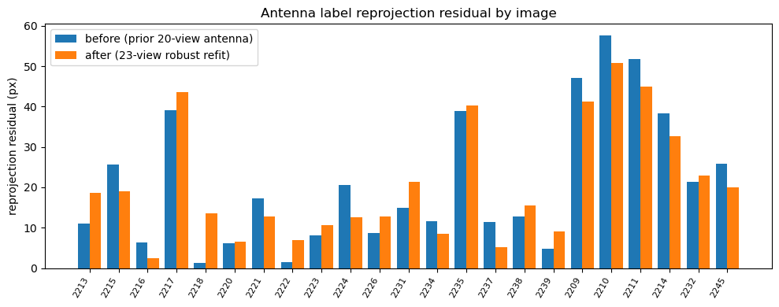

```python
fig, ax = plt.subplots(figsize=(10, 4))
x = np.arange(len(keys))
after_px = [after[k]['error_px'] for k in keys]
before_px = [before[k]['error_px'] for k in keys]
ax.bar(x - 0.2, before_px, width=0.4, label='before (prior 20-view antenna)')
ax.bar(x + 0.2, after_px, width=0.4, label='after (23-view robust refit)')
ax.set_xticks(x); ax.set_xticklabels(keys, rotation=60, ha='right', fontsize=8)
ax.set_ylabel('reprojection residual (px)')
ax.set_title('Antenna label reprojection residual by image')
ax.legend()
fig.tight_layout()
fig.savefig('_b2_ant_diag.png', dpi=140)
plt.show()
```

### 3b. Caveats — read before using this position downstream

1. **Camera poses are held fixed** for this triangulation; it is not a joint refit, so it does not absorb camera pose error into the antenna estimate (by design), but it also cannot correct for camera pose error either.
2. **Five images have residuals of 40–58 px** (2209, 2210, 2211, 2217, 2235), corresponding to ray misses of 1.0–1.6 m. Per `ANTENNA_REPICK.md`, a local parallax-aware scan on one of these (2209) confirmed sub-meter camera adjustments preserve terrain residuals but do not remove the antenna residual — forcing it to zero raises held-out terrain residuals to ~13 px. **These labels must not be treated as exact Gaussian observations**; a robust mixture/error-floor or an added calibration degree of freedom is required before any downstream MCMC use.
3. LOO median (20.28 px) exceeds the plain fit median (15.47 px), i.e. the solution is somewhat sensitive to any single view — expected given the residual spread above, not evidence of a fitting bug.

## 4. Summary

| Target | Best estimate (E, N, U) m | Uncertainty | Status |
| --- | --- | --- | --- |
| Transmitter | [1652.198, 2025.104, 1684.384] | **±1.5 m hard bracket** (not a sigma) | No accepted generation; use bracketed product |
| Antenna | [1655.868, 2030.923, 1777.397] | Not yet bracketed — residual too large/non-Gaussian on 5/23 views | Provisional; not MCMC-ready |

## 5. Decision requested

1. **Transmitter position:** may downstream work (e.g. delay/geometry calculations) cite `[1652.198, 2025.104, 1684.384] m ± 1.5 m` (hard bracket) as the current defensible value, given that no fit generation is accepted and the ~1 m vertical group disagreement remains unresolved?
2. **Transmitter follow-up:** is it worth spending further optimizer time to resolve the vertical group disagreement (free the established-camera poses in the joint fit, or downweight/exclude the ultra-close 2199/2203 cameras), or should the ±1.5 m bracket stand as the delivered product for now and this be logged as a known open item?
3. **Antenna position:** the current best estimate `[1655.868, 2030.923, 1777.397] m` has no formal uncertainty bracket analogous to the transmitter's, and 5/23 labels have residuals too large to treat as Gaussian. Should B2's antenna deliverable be (a) a similar bracketing exercise over antenna-fit generations, (b) a robust-error-floor refit that down-weights the 5 problem views, or (c) is the current point estimate sufficient for the next downstream consumer's precision needs?

No further transmitter/antenna refit work has been started pending this decision — per fleet-freeze protocol, this agent is not self-assigning follow-on optimizer work.